# Predicting Type of Exercise

Sarah Friedman

# Background

The purpose of this exercise is to generate a model that can predict exercise type using data related to exercise measurements.

# Data

For this exercise, two data sets were provided: (1) a data set named “training” with 19622 observations and 160 variables and a labelled outcome variable “classe” and (2) a data set named “testing” with 20 observations and 160 variables. The “testing” data set does not include a labeled outcome variable, and as such results can not be validated, so the testing data set will not be used for testing. Rather, the “training” data set was divided into two sets: training data (70%) and testing data (30%).

Data Source: [Human Activity Recognition](http://groupware.les.inf.puc-rio.br/har)

## Missing Data

Observations with missing data were removed, as were columns without predictive value, i.e. where all of the values were the same. This resulted in a data set with 152 variables, and 229 observations in a training set and 95 observations in a testing set.

# Model Building

Through feature selection with classification trees, predictors with any importance were used in the final training model, as indicated below.

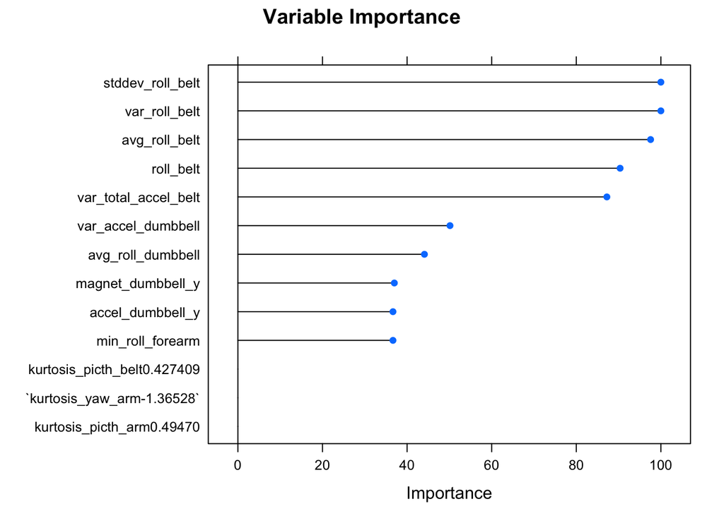

# Final Model and Cross Validation

| Accuracy | 0.8315789 |
| --- | --- |
| Kappa | 0.7853107 |
| AccuracyLower | 0.7409518 |
| AccuracyUpper | 0.9005563 |
| AccuracyNull | 0.2736842 |
| AccuracyPValue | 0.0000000 |
| McnemarPValue | NaN |